# Georreferencias sin API

Eduardo Alanis

2024-10-07

Para usar este código, la base de datos que deseas georreferenciar debe incluir las siguientes variables: Calle, Colonia, Código Postal, Ciudad, Estado y País.

```r
# Cargar librerias, estas son posibles que se pueden usar
library(haven)    # Carga la librería 'haven' para leer y escribir archivos SPSS, Stata y SAS.
library(foreign)  # Carga la librería 'foreign', también utilizada para leer archivos en diferentes formatos estadísticos.
library(sf)       # Carga la librería 'sf' para manejar y analizar datos espaciales (geometrías vectoriales).
library(readxl)   # Carga la librería 'readxl' para leer archivos Excel.
```

```r
# Abres el archivo que se va utilizar, en este ejemplo se hara uso de un archivo Excel.
datos = read_excel(path = "C:/Users/eagel/OneDrive/Escritorio/Lalo/Escuela/Servicio Social/Agosto/Archivos Utilizados/Directorio final 2023 sectur (1) (1).xlsx", sheet = 1, col_names = TRUE, skip = 1)

# Escribes de manera correcta el nombre de las columnas que se van utilizar.
columnas_utilizar = c("NOMBRE DEL ESTABLECIMIENTO", "MUNICIPIO", "LOCALIDAD", "CALLE", "COLONIA", "CP", "LATITUD","LONGITUD", "LATITUD_NUEVOS", "LONGITUD_NUEVOS")

datos = datos[, columnas_utilizar]  # Filtras los datos, solo con las columnas que son de tu interes
```

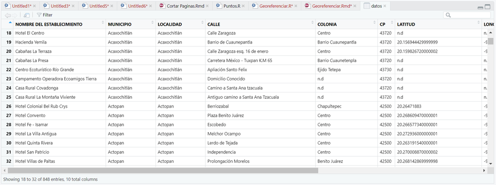

Observamos que en la columna de latitud hay valores “n.d.” y estos son de nuestro interés, ya que las filas que contienen esto se van a georeferenciar.

```r
indices_datos = function(df){           # Guarda el indice de las filas que tienen "n.d"
  indices <- which(df$LATITUD == "n.d")
  return(indices)
}   # Funcion indices, esta seguramente deberia ser modifica por NA dependiendo la base

filtrar_datos = function(df) {           # Generas una funcion para filtrar las que tienen "n.d"
  df_filtrado = df[df$LATITUD == "n.d",]
  return(df_filtrado)
}  # Funcion para filtrar, esta seguramente debera ser modificado por NA dependiendo la base
```

En la línea de código anterior, probablemente debas modificarla, ya que en la mayoría de las bases de datos suelen usar “NA” en lugar de “n.d”.

```r
datos_filtrados = datos       # Crea una variable que almacenará los datos que se utilizarán para filtrar.
indices_f = indices_datos(df = datos_filtrados)      # Se aplica la funcion indices_datos
resultados_f = filtrar_datos(df = datos_filtrados)   # Se aplica la funcion filtrar_datos
resultados_f = resultados_f[c(1:25),]
```

```r
georefenciar_datos = function(df){
  library(tidygeocoder)  # Carga la libreria que hace georeferencias

  # Creas matrices vacías para almacenar resultados
  todos_8 = matrix(data = NA, nrow = 0, ncol = 8)
  todos_20 = matrix(data = NA, nrow = 0, ncol = 20)

  for (i in 1:nrow(df)) {
    # Geocodificación de la fila actual
    result = geo(street = df$CALLE[i], county = df$COLONIA[i], postalcode = df$CP[i],
                 city = df$MUNICIPIO[i], state = "Hidalgo", country = "Mexico",
                 method = "osm", full_results = TRUE)

    result = as.matrix(result)  # Convierte a matriz
    numero_columnas = ncol(result)  # Obtiene el número de columnas

    # Imprimir progreso y datos intermedios
    print(paste("Fila:", i, "- Número de columnas:", numero_columnas))

    # Dependiendo del número de columnas, se asigna a diferentes matrices
    if (numero_columnas == 8) {
      todos_8 = rbind(todos_8, result)
    } else if (numero_columnas == 20) {
      todos_20 = rbind(todos_20, result)
    }
  }

  # Verificación antes de devolver resultados
  if (nrow(todos_20) > 0) {
    print("Matriz final - todos_20:")
    print(todos_20)
    return(as.matrix(todos_20))  # Regresa la matriz final
  } else {
    print("No se encontraron resultados con 20 columnas.")
    return(NULL)
  }
}
```

Uso de la funcion

```r
georefencias_correctas = georefenciar_datos(df = resultados_f)
```

### Nota:

Este código para georreferenciar no es muy preciso. Hicimos una prueba con 100 lugares y solo logró georreferenciar 74 de ellos. Al comparar esos 74 lugares con sus ubicaciones reales, solo 7 estaban correctos. Las demás tenían una diferencia de al menos 10 metros, y la mayor diferencia fue de 30 kilómetros.

Este método para georreferenciar es 100% gratuito. Sin embargo, hay otras opciones, como la API de Google, que tienen un límite en el número de usos y requieren una tarjeta de crédito para acceder.